# Prelim_data_exploration

Nicole Hill

15/09/2021

## Plots of environmental layers for the shelf (defined as <3000m here) with location of samples.

Haven’t used fancy SOmap as it takes way too long with 500m rasters. Revisit if needed for publication figures.

### Bathymetry derivatives

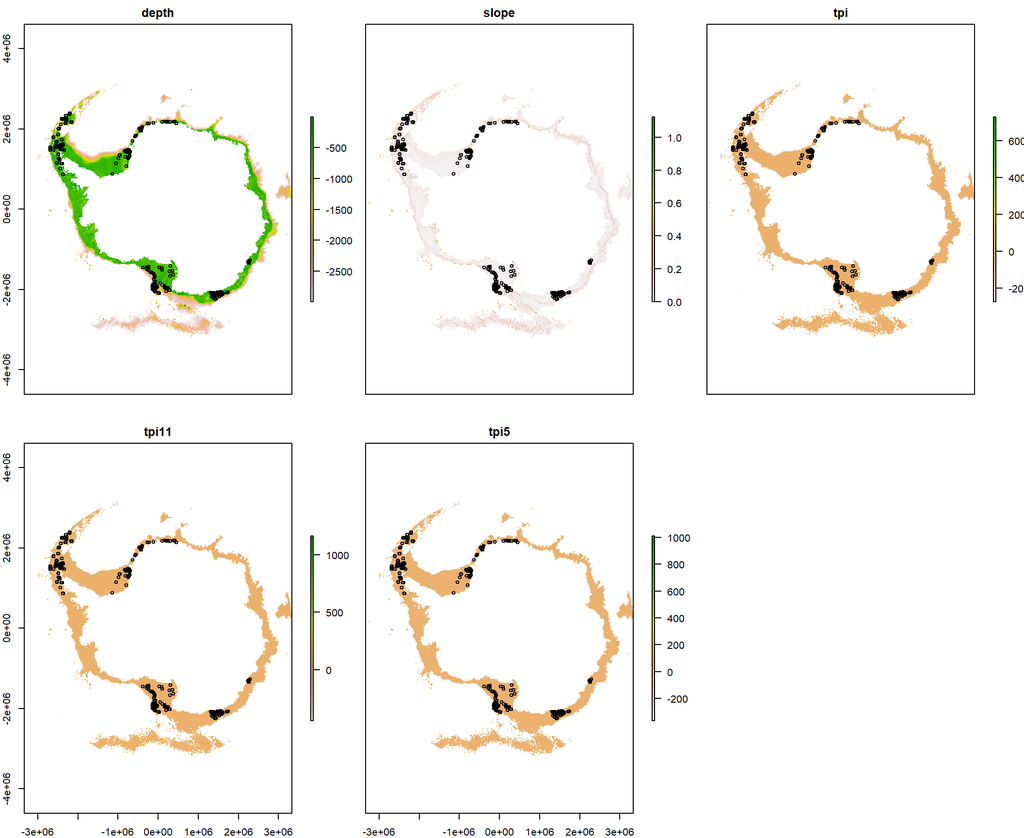

### Ice

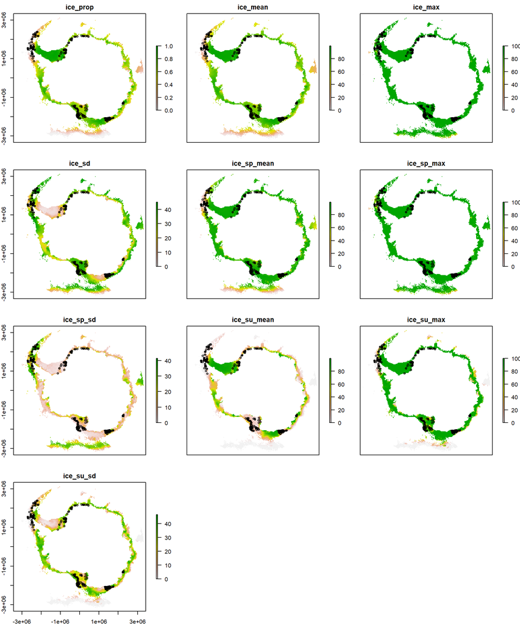

### SST

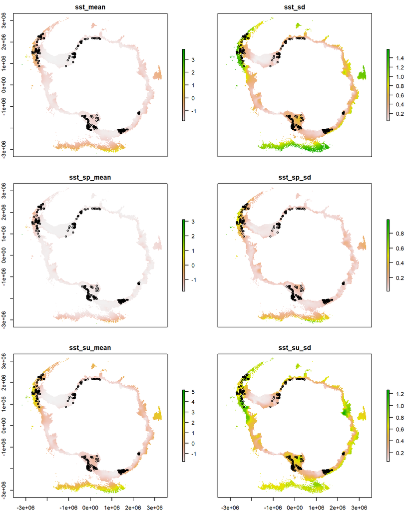

### NPP

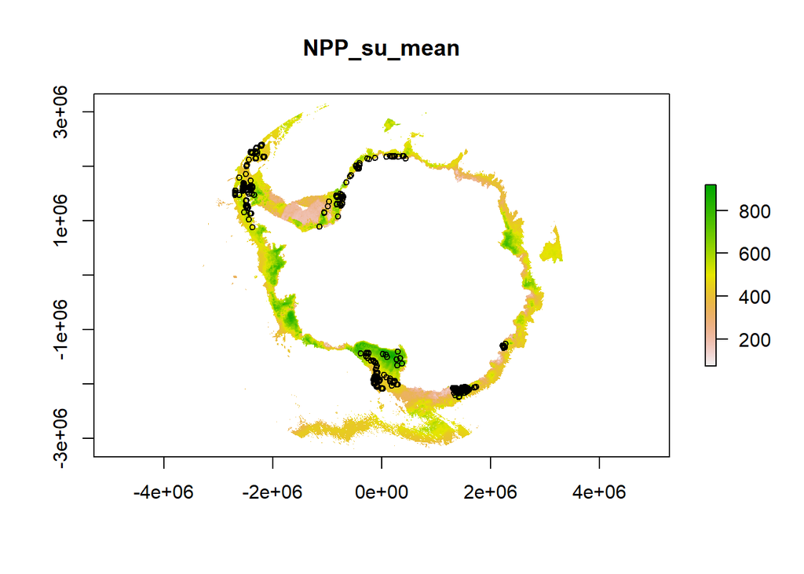

### Seafloor parameters

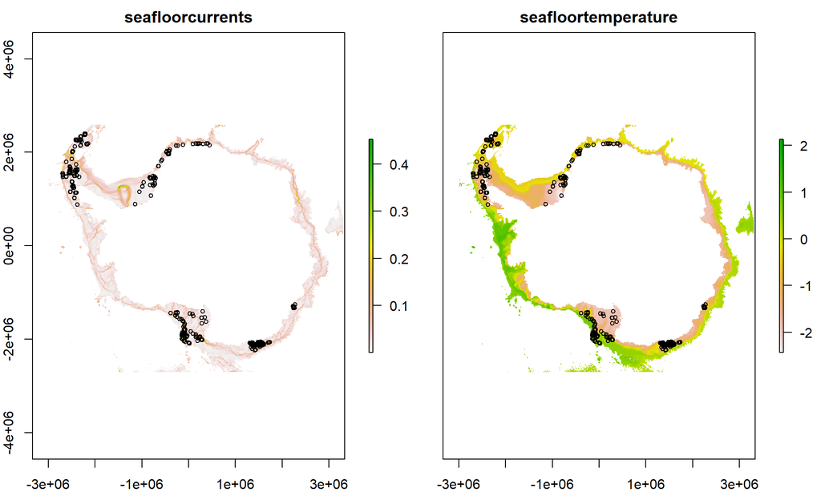

### Geomorphology

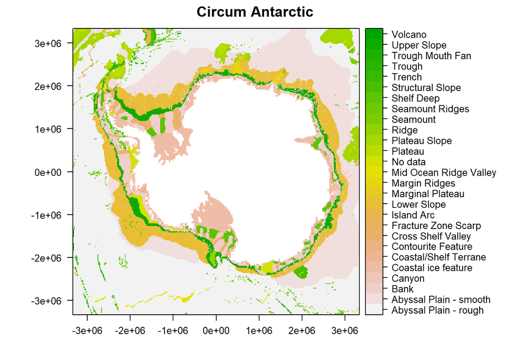

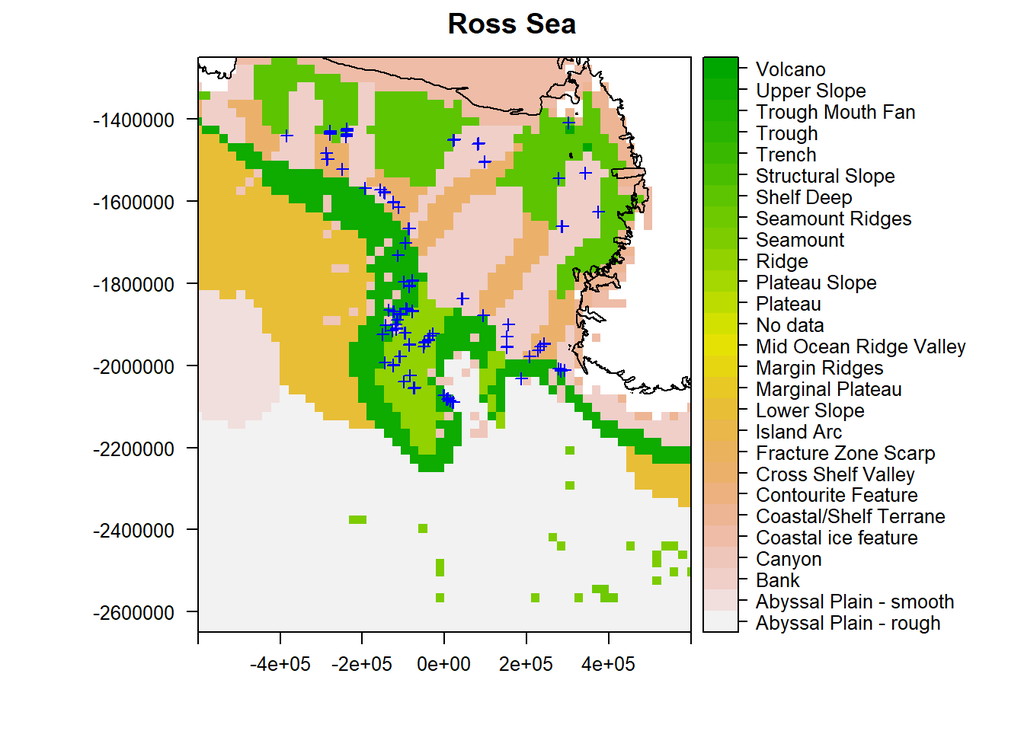

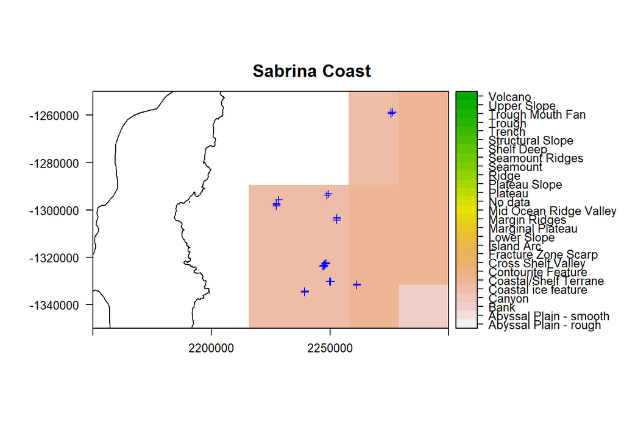

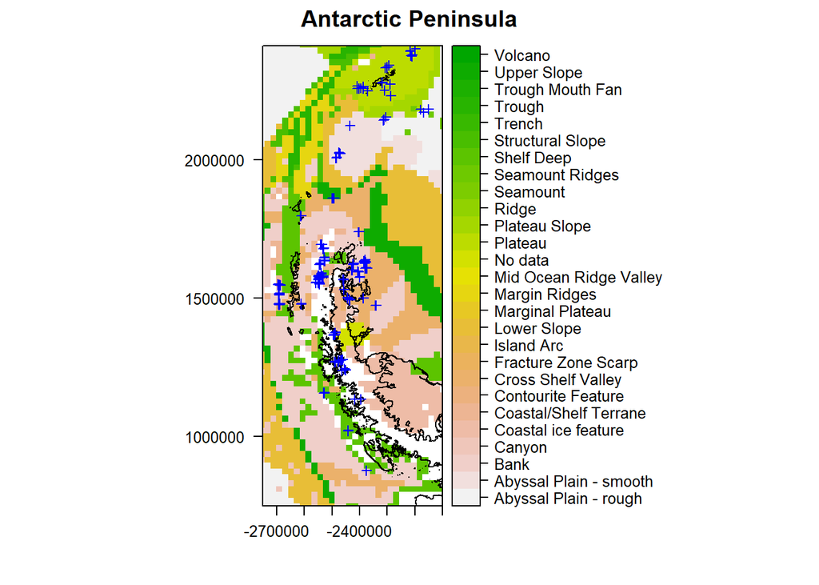

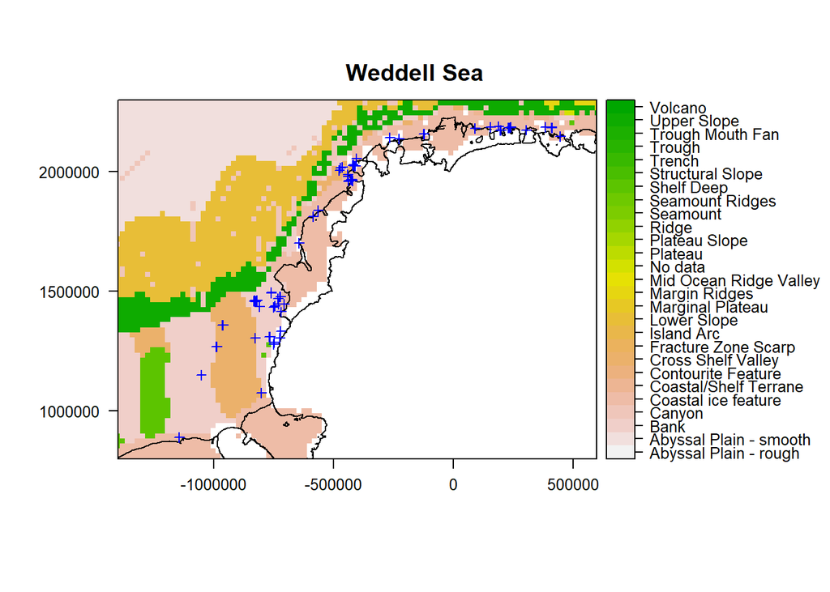

## Density/distribution plots of environmental variables

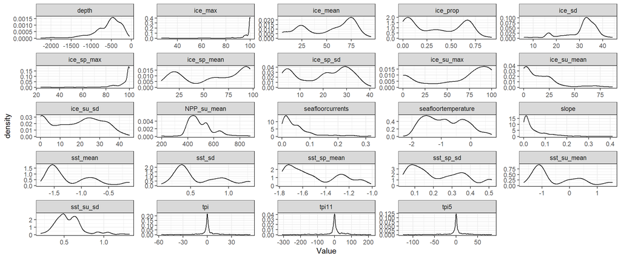

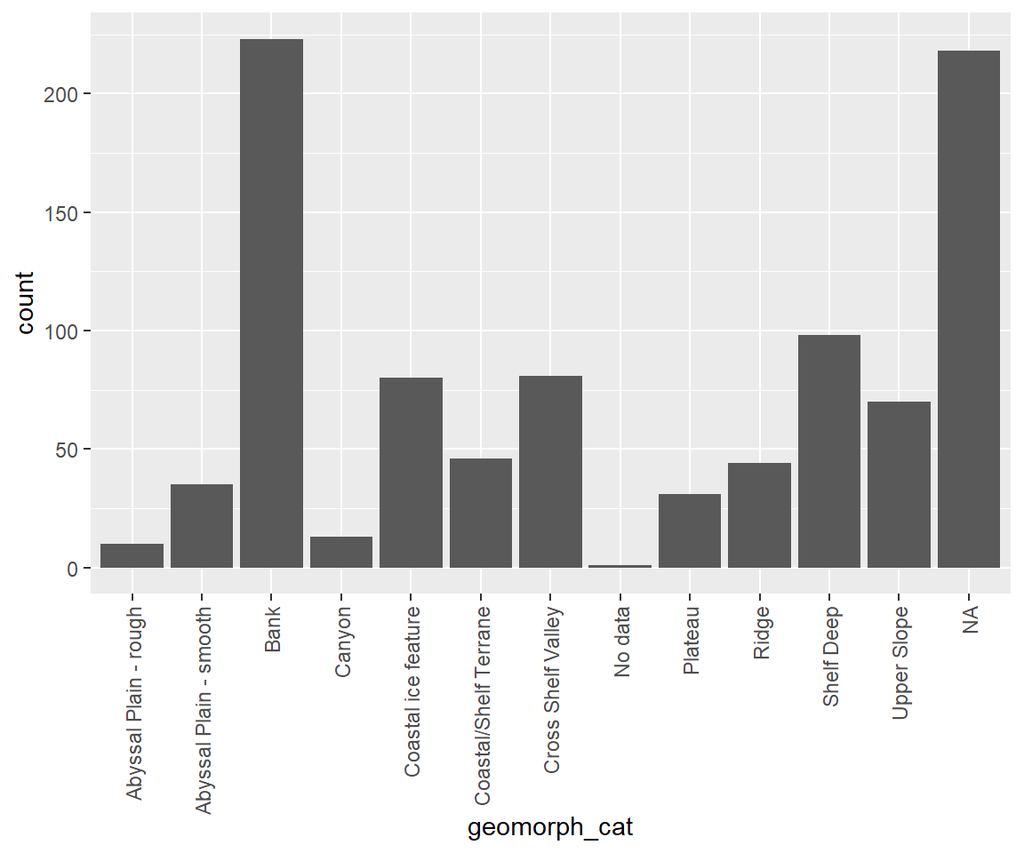

## Biplots with correlation between environmental variables at image cells

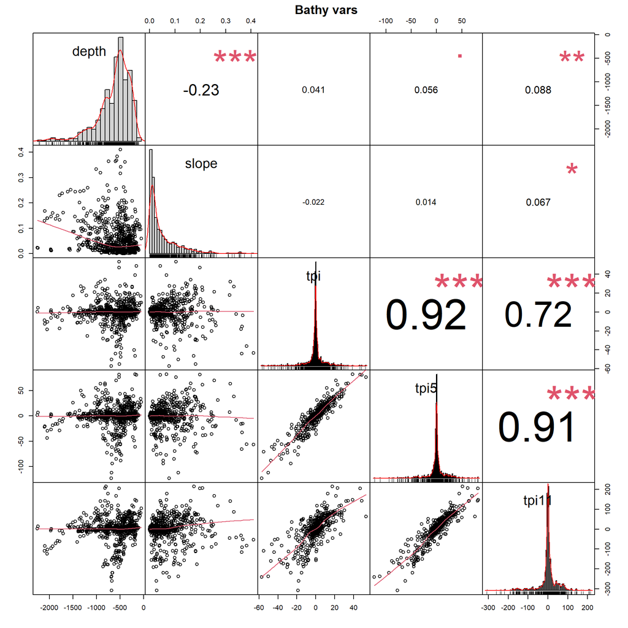

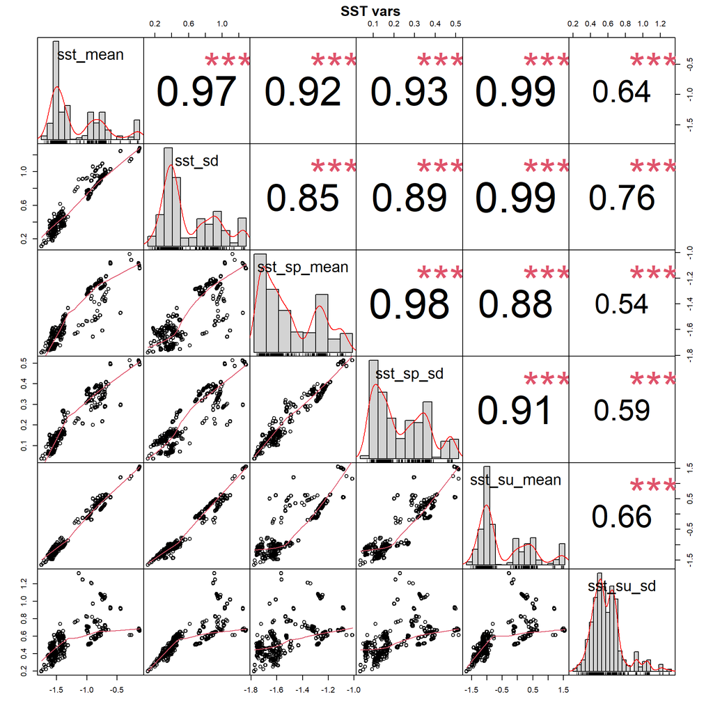

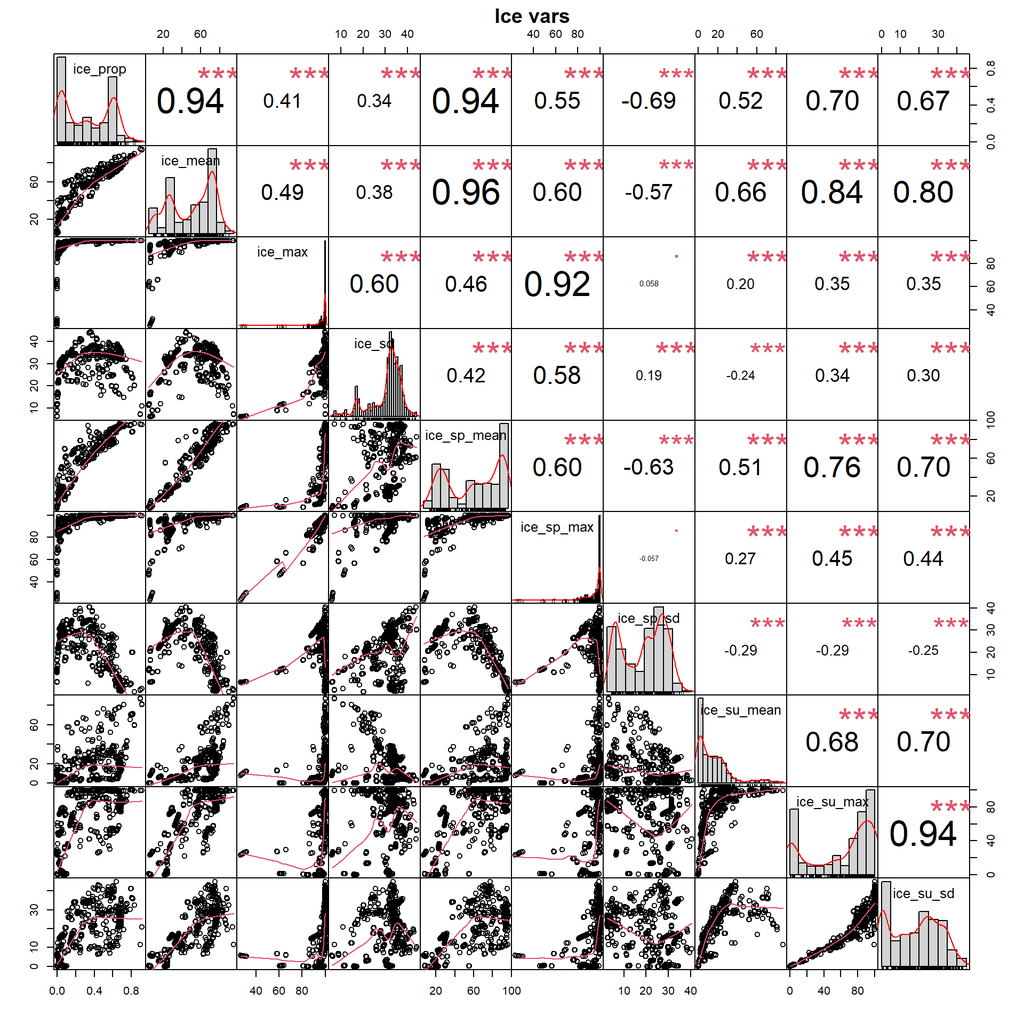

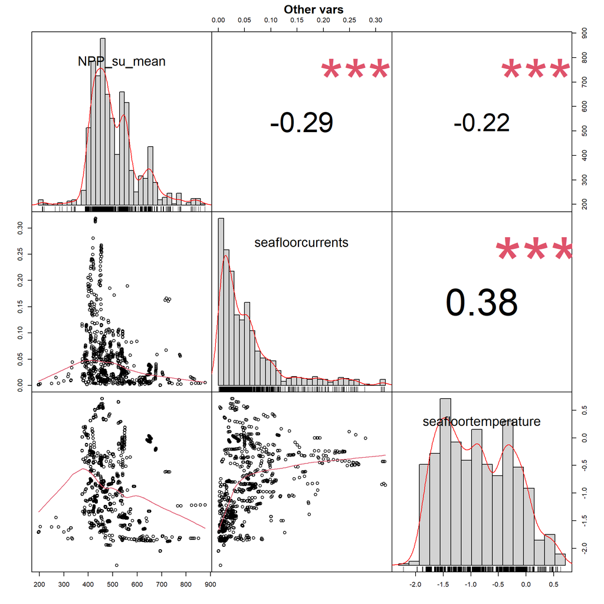

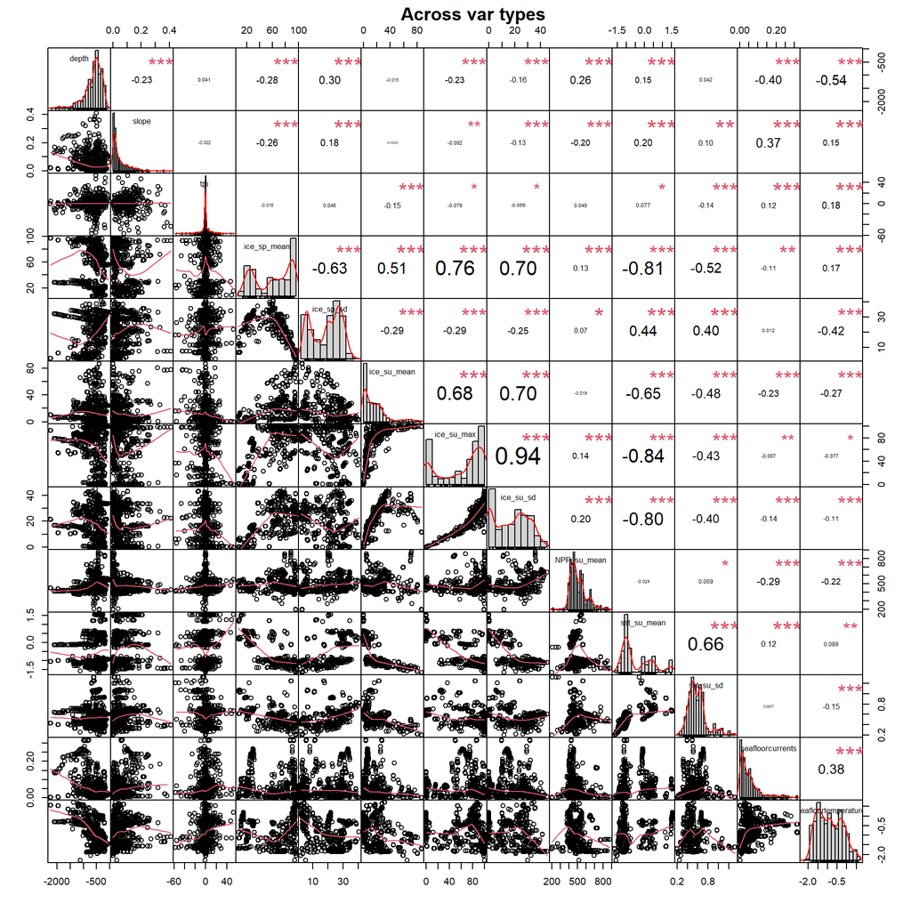

- TO DO: environmental coverage of subset of likely variables using Jan’s shiny app code*

## Image data

1. Distribution of area and image quality by: survey, institute, platform - need this info added to image metadata
2. Distribution of number of images per cell -DONE
3. Temporal (and spatial) distribution of images- need date for temporal distribution
4. Histogram of Distance between images (need to think about how to avoid going over land)-TO DO

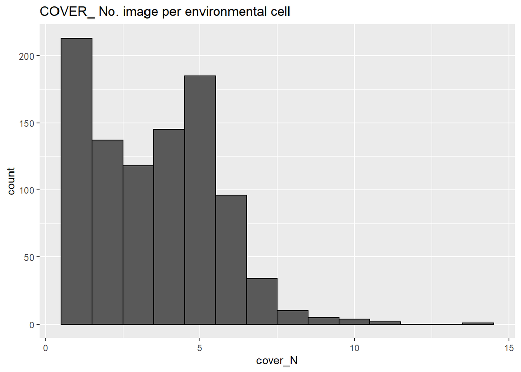

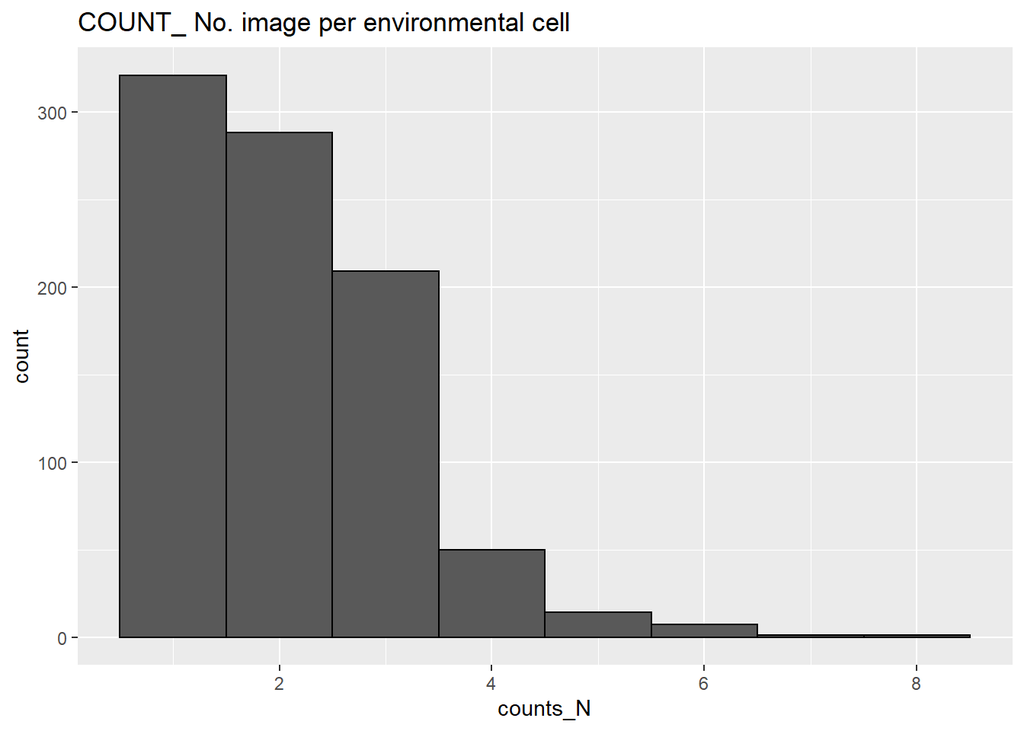

### Spatial distribution of number of images per cell.

to add same plot of counts_N

#### Ross Sea

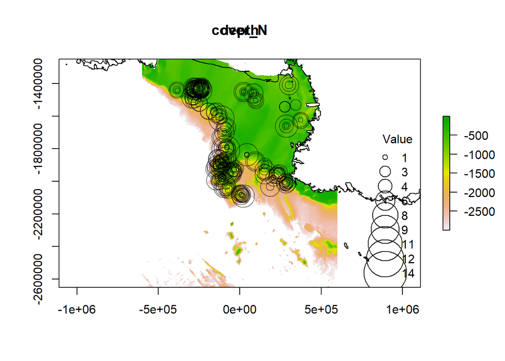

#### East Antarctica

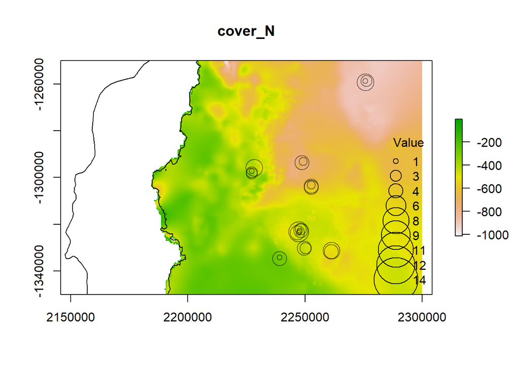

#### Antarctic Peninsula

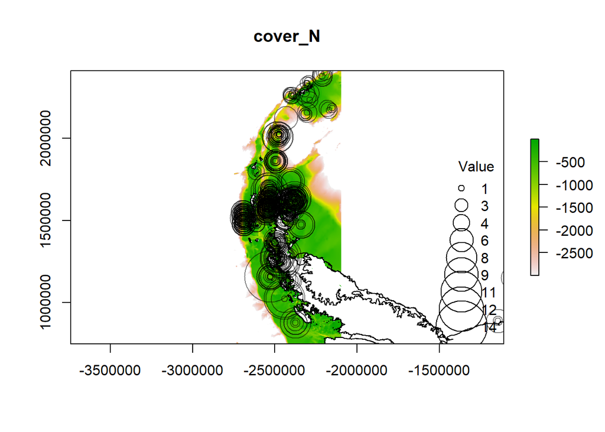

#### Weddell Sea

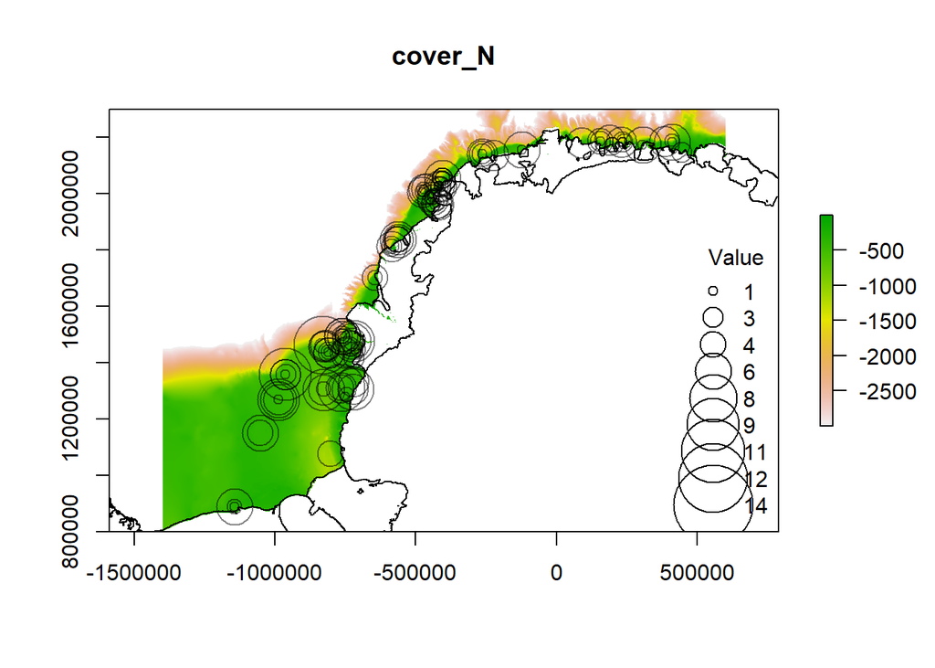

## Biological Data

requires matching cell level annotations with environmental data (same as 1 above -Nic)  
Jan to add number of images/number of points to each cover/count at cell level file - done

1. prevalence of each biological taxa (will help inform any aggregation)
2. key taxa spatial bubbleplots
3. Any platform -related effects??
4. GAMS with env data